# ANÁLISE DOS PROCESSOS SELETIVOS

Planejo aqui analisar as inscrições e resultados de efetivação dos últimos Processos Seletivos da Ecomp.

Explicação:

- PS 1 = 2016-1
- PS 2 = 2016-2
- PS 3 = 2017-1
- PS 4 = 2017-2

  Como TODO candidato tem um nome, podemos utilizar ele para realizar a contagem nos groupBy! Em alguns casos, renomeei a coluna para refletir o que esta indica.

Importando as bibliotecas necessárias:

```python
import numpy as np # linear algebra
import pandas as pd # data processing, CSV file I/O (e.g. pd.read_csv)

# visualization
import seaborn as sns
import matplotlib.pyplot as plt
%matplotlib inline

# Pegando os dados
inscricoes_df = pd.read_csv('inscricoes.csv', sep=',')
inscricoes_df[['PS']] = inscricoes_df[['PS']].astype('int')
```

Prévia dos dados

```python
inscricoes_df.columns.values
```

```
array(['Nome', 'GRR', 'Curso', 'Amigos', 'Facebook', 'Semana Acadêmica',
       'Semana dos Calouros', 'PS', 'Efetivado'], dtype=object)
```

```python
inscricoes_df.describe()
```

|  | PS | Efetivado |
| --- | --- | --- |
| count | 182.000000 | 41.0 |
| mean | 2.593407 | 1.0 |
| std | 1.029703 | 0.0 |
| min | 1.000000 | 1.0 |
| 25% | 2.000000 | 1.0 |
| 50% | 3.000000 | 1.0 |
| 75% | 3.000000 | 1.0 |
| max | 4.000000 | 1.0 |

```python
inscricoes_df.head()
```

|  | Nome | GRR | Curso | Amigos | Facebook | Semana Acadêmica | Semana dos Calouros | PS | Efetivado |
| --- | --- | --- | --- | --- | --- | --- | --- | --- | --- |
| 0 | Rodrigo Yuji Koga Kuroda | GRR20166364 | BCC | NaN | NaN | NaN | Semana dos Calouros | 1 | NaN |
| 1 | Guilherme Morais Lopes dos Santos | 20163043 | BCC | NaN | NaN | NaN | Semana dos Calouros | 1 | NaN |
| 2 | Lucas Sidnei dos Santos | 20163040 | BCC | NaN | NaN | NaN | Semana dos Calouros | 1 | NaN |
| 3 | Lucas Eduardo | NaN | BCC | NaN | NaN | NaN | NaN | 1 | NaN |
| 4 | Bruna Luisa Romanichen Andrade | NaN | IBM | NaN | NaN | NaN | Semana dos Calouros | 1 | NaN |

```python
inscricoes_df.tail()
```

|  | Nome | GRR | Curso | Amigos | Facebook | Semana Acadêmica | Semana dos Calouros | PS | Efetivado |
| --- | --- | --- | --- | --- | --- | --- | --- | --- | --- |
| 177 | Rhonner Matheus Nunes Afanaci | grr20175453 | TADS | Amigos | NaN | NaN | Semana dos Calouros | 4 | 1.0 |
| 178 | Roberta Samistraro Tomigian | 20171631 | BCC | Amigos | NaN | NaN | Semana dos Calouros | 4 | 1.0 |
| 179 | Roderlei Thimoteo Junior | GRR20163317 | TADS | Amigos | NaN | NaN | Semana dos Calouros | 4 | NaN |
| 180 | Taysla Farias | GRR20170235 | TADS | NaN | NaN | NaN | Semana dos Calouros | 4 | NaN |
| 181 | Yuri Nicolaiko | GRR20175468 | TADS | Amigos | NaN | NaN | NaN | 4 | 1.0 |

Com o head e tail, podemos observar que as colunas [Amigos, Facebook e Semana Acadêmica] funcionam de maneira complementar. Também, analisando o 3, "Lucas Eduardo", podemos observar que nem sempre os campos estão preenchidos.

```python
inscricoes_df.groupby('PS').count()
```

| PS | Nome | GRR | Curso | Amigos | Facebook | Semana Acadêmica | Semana dos Calouros | Efetivado |
| --- | --- | --- | --- | --- | --- | --- | --- | --- |
| 1 | 40 | 35 | 40 | 6 | 5 | 0 | 28 | 5 |
| 2 | 28 | 27 | 28 | 9 | 18 | 5 | 0 | 11 |
| 3 | 80 | 72 | 80 | 0 | 0 | 0 | 0 | 16 |
| 4 | 34 | 33 | 34 | 21 | 12 | 0 | 14 | 9 |

É fácil perceber que os Processos Seletivos de começo de ano [2016-1, 2017-1] tem uma quantidade bem maior de inscritos. Também pode-se ver o crescimento de 2016 para 2017.

Além disso, pode-se observar que os processos seletivos de segundo semestre tem mais recomendações de amigos do que os do primeiro semestre.

Uma falha grande em nossos dados é a ausência da origem da inscrição durante o PS 2017-1. Isso poderá afetar nossa análise da origem dos membros.

```python
inscricoes_df[['Curso', 'PS']].groupby('Curso').count()
```

| Curso | PS |
| --- | --- |
| BCC | 82 |
| IBM | 16 |
| TADS | 84 |

Podemos ver que a predominância de inscrições de BCC sobre TADS é quase nula. Também, é possível observar que a frequência de inscrições de IBM é baixíssima ao longo dos anos.

```python
# Contagem de inscritos de cada curso, em cada PS
insc_curso_ps_df = inscricoes_df[['Nome', 'Curso', 'PS']].groupby(['Curso', 'PS']).count()
insc_curso_ps_df = insc_curso_ps_df.reset_index()

# Ordenando os valores em relação ao PS
insc_curso_ps_df.sort_values(by=['PS'], ascending=True, inplace=True)
display(insc_curso_ps_df)
```

|  | Curso | PS | Nome |
| --- | --- | --- | --- |
| 0 | BCC | 1 | 22 |
| 4 | IBM | 1 | 4 |
| 8 | TADS | 1 | 14 |
| 1 | BCC | 2 | 14 |
| 5 | IBM | 2 | 1 |
| 9 | TADS | 2 | 13 |
| 2 | BCC | 3 | 31 |
| 6 | IBM | 3 | 10 |
| 10 | TADS | 3 | 39 |
| 3 | BCC | 4 | 15 |
| 7 | IBM | 4 | 1 |
| 11 | TADS | 4 | 18 |

Observa-se que nos últimos dois Processos Seletivos, o curso de TADS teve mais inscritos que BCC e IBM. Porém, isso foi crescendo aos poucos!

Mas imagens explicam melhor!

| PS | Inscritos |
| --- | --- |
| 1 | 40 |
| 2 | 28 |
| 3 | 80 |
| 4 | 34 |

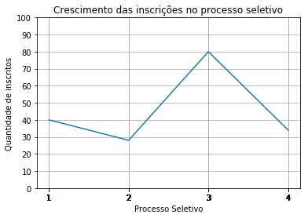

```python
insc_total_df = inscricoes_df[['Nome', 'PS']].groupby(['PS']).count()
insc_total_df = insc_total_df.rename(columns={'Nome': 'Inscritos'})
display(insc_total_df)

plt.plot(insc_total_df['Inscritos'])
plt.xticks(inscricoes_df['PS'])
plt.yticks(np.linspace(0, 100, 11))
plt.xlabel('Processo Seletivo')
plt.ylabel('Quantidade de inscritos')
plt.title('Crescimento das inscrições no processo seletivo')
plt.grid(True)
plt.show()
```

Efetuando algumas comparações mais complexas:

| PS | Efetivados |
| --- | --- |
| 1 | 5 |
| 2 | 11 |
| 3 | 16 |
| 4 | 9 |

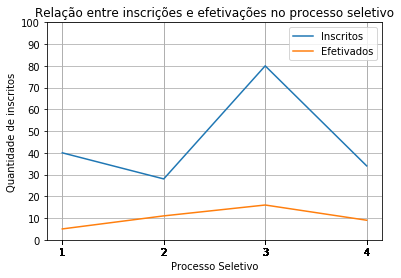

```python
insc_efet_total_df = inscricoes_df.loc[inscricoes_df['Efetivado'] == 1]
insc_efet_total_df = insc_efet_total_df[['PS', 'Efetivado']].groupby(['PS']).count()
insc_efet_total_df = insc_efet_total_df.rename(columns={'Efetivado': 'Efetivados'})
display(insc_efet_total_df)

#Conjunto de 11 valores entre 0 e 100
y_label = np.linspace(0, 100, 11)

plt.plot(insc_total_df['Inscritos'])
plt.plot(insc_efet_total_df['Efetivados'])
plt.xticks(inscricoes_df['PS'])
plt.yticks(y_label)
plt.xlabel('Processo Seletivo')
plt.ylabel('Quantidade de inscritos')
plt.title('Relação entre inscrições e efetivações no processo seletivo')
plt.grid(True)
plt.legend()
plt.show()
```

Analisando as inscrições de cada curso em cada PS

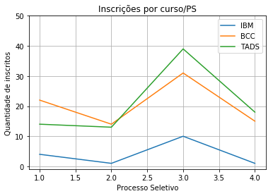

```python
# Refazendo a contagem de inscritos de cada curso, em cada PS
insc_curso_ps_df = inscricoes_df[['Nome', 'Curso', 'PS']].groupby(['Curso', 'PS']).count()
insc_curso_ps_df = insc_curso_ps_df.reset_index()

# Conjunto de 11 valores entre 0 e 100
y_label = np.linspace(0, 50, 6)

# Pegando membros de IBM
insc_ibm_ps_df = insc_curso_ps_df[insc_curso_ps_df.Curso == 'IBM']
insc_ibm_ps_df = insc_ibm_ps_df.rename(columns={'Nome': 'IBM'})
plt.plot(insc_ibm_ps_df['PS'], insc_ibm_ps_df['IBM'])

# Pegando membros de BCC
insc_bcc_ps_df = insc_curso_ps_df[insc_curso_ps_df.Curso == 'BCC']
insc_bcc_ps_df = insc_bcc_ps_df.rename(columns={'Nome': 'BCC'})
plt.plot(insc_bcc_ps_df['PS'], insc_bcc_ps_df['BCC'])

# Pegando membros de TADS
insc_tads_ps_df = insc_curso_ps_df[insc_curso_ps_df.Curso == 'TADS']
insc_tads_ps_df = insc_tads_ps_df.rename(columns={'Nome': 'TADS'})
plt.plot(insc_tads_ps_df['PS'], insc_tads_ps_df['TADS'])

plt.yticks(y_label)
plt.xlabel('Processo Seletivo')
plt.ylabel('Quantidade de inscritos')
plt.title('Inscrições por curso/PS')
plt.grid(True)
plt.legend()
plt.show()
```